# **[Universidade Federal Rural de Pernambuco](http://ufrpe.br/)** **[Departamento de Matemática](http://www.dm.ufrpe.br/)** **[Disciplina: Cálculo M I](https://sites.google.com/site/ricardonunesmachadojr/disciplinas/c%C3%A1lculo-mi)** **[Prof. Ricardo Machado](https://sites.google.com/site/ricardonunesmachadojr/)**

## [Índice de Aulas](https://sagectu.com.br/calculo1.github.io/index.html) Aula 2

## Derivadas de $x^n$ e $\sqrt[n]{x}$. Derivadas de $e^x$ e $\ln{x}$. Derivadas das Funções Trigonométricas.

# Referências:

[figure not shown]

[figure not shown]

### Observação: Nota de aula produzida usando o software [SageMath](http://www.sagemath.org/), usando o notbook [Jupyter](https://jupyter.org/). Use o SageMathCell com vários exemplos em: sagectu.com.br/sagecell.html

## 1 - Derivadas de $x^n$ e $\sqrt[n]{x}$.

## Teorema. Seja $n\neq0$ um natural. São válidas as fórmulas de derivação:

## a) $f(x)=x^n \Rightarrow f'(x)=nx^{n-1}$. b) $f(x)=x^{-n} \Rightarrow f'(x)=-nx^{-n-1}$, $x\neq0$. c) $f(x)=x^{\frac{1}{n}} \Rightarrow f'(x)=\frac{1}{n}x^{\frac{1}{n}-1}$, onde $x>0$ se $n$ for par e $x\neq0$ se $n$ for ímpar $(n\geq2)$.

## Dem.

## a) $f'(x) = \displaystyle \lim_{h\rightarrow 0} \frac{(x+h)^n-x^n}{h}$ (faça a mudança de variável $x+h=t$), logo, $f'(x) = \displaystyle \lim_{t\rightarrow x} \frac{t^n-x^n}{t-x} = \lim_{t\rightarrow x} (t^{n-1}+t^{n-2}x+t^{n-3}x^2+\cdots+x^{n-1})$. Assim, $~~f'(x) = (x^{n-1}+x^{n-1}\cdots+x^{n-1}) = nx^{n-1}$.

## b) $f'(x) = \displaystyle \lim_{h\rightarrow 0} \frac{\frac{1}{(x+h)^n}-\frac{1}{x^n}}{h} = \lim_{h\rightarrow 0} -\frac{(x+h)^n-x^n}{h}\cdot\frac{1}{(x+h)^nx^n}$.

## Como $\displaystyle \lim_{h\rightarrow 0} \frac{(x+h)^n-x^n}{h} = nx^{n-1} ~~~~ e ~~~~ \lim_{h\rightarrow 0} \frac{1}{(x+h)^nx^n} = \frac{1}{x^{2n}}$ Temos $f'(x) = -nx^{n-1}\cdot\dfrac{1}{x^{2n}}=-nx^{-n-1}$.

## c) $f'(x) = \displaystyle \lim_{h\rightarrow 0} \frac{\sqrt[n]{x+h}-\sqrt[n]{x}}{h} = \lim_{t\rightarrow x} \frac{\sqrt[n]{t}-\sqrt[n]{x}}{t-x}$

## Fazendo $u=\sqrt[n]{t}$ e $v=\sqrt[n]{x}~~(t\rightarrow x \Rightarrow u\rightarrow v)$ resulta: $f'(x) = \displaystyle \lim_{u\rightarrow v} \frac{u-v}{u^n-v^n} = \lim_{u\rightarrow v} \frac{1}{\frac{u^n-v^n}{u-v}}=\frac{1}{nv^{n-1}}$. Assim, para $x\neq 0$ e $x$ no domínio de $f$, $f'(x)=\frac{1}{n\sqrt[n]{x^{n-1}}}$ ou seja, $f'(x)=\frac{1}{n}x^{\frac{1}{n}-1}$.

## Exercício 1. Seja $f(x)=x^4$. Calcule.

## a) $f'(x)$ b) $f'\left( \frac{1}{2} \right)$

```python
diff(x^4, x).show()
```

$$\newcommand{\Bold}[1]{\mathbf{#1}}4 \, x^{3}$$

```python
diff(x^4, x)(x=1/2).show()
```

$$\newcommand{\Bold}[1]{\mathbf{#1}}\frac{1}{2}$$

## Exercício 2. Seja $f(x)=x^3$.

## a) Calcule $f'(x)$ b) Determine a equação da reta tangente ao gráfico de $f$ no ponto de abscissa $1$. (ou seja, $x=1$)

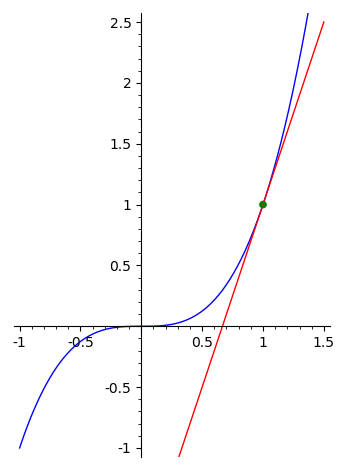

```python
grafico_f_tan(x^3, 1, (-1,1.5), (-1, 2.5))
```

```python
diff(x^3, x).show()
```

$$\newcommand{\Bold}[1]{\mathbf{#1}}3 \, x^{2}$$

```python
y = var('y')
f = x^3
(y == diff(f, x)(x=1)*(x-1)+f(x=1)).show()
```

$$\newcommand{\Bold}[1]{\mathbf{#1}}y = 3 \, x - 2$$

## Exercício 3. Calcule $f'(x)$ sendo

## a) $f(x)=x^{-3}$. b) $f(x)=\dfrac{1}{x^5}$.

```python
diff(x^(-3), x).show()
```

$$\newcommand{\Bold}[1]{\mathbf{#1}}-\frac{3}{x^{4}}$$

```python
diff(1/x^5, x).show()
```

$$\newcommand{\Bold}[1]{\mathbf{#1}}-\frac{5}{x^{6}}$$

## Exercício 4. Seja $f(x)=\sqrt{x}$. Calcule

## a) $f'(x)$. b) $f'(3)$.

```python
diff(x^(1/2), x).show()
```

$$\newcommand{\Bold}[1]{\mathbf{#1}}\frac{1}{2 \, \sqrt{x}}$$

```python
diff(x^(1/2), x)(x=3).show()
```

$$\newcommand{\Bold}[1]{\mathbf{#1}}\frac{1}{6} \, \sqrt{3}$$

## Exercício 5.

## Determine a equação da reta tangente ao gráfico de $f(x)=\sqrt[3]{x}$ no ponto de abscissa 8.

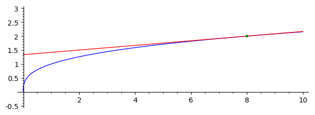

```python
grafico_f_tan(x^(1/3), 8, (0, 10), (-0.5, 3))
```

```python
y = var('y')
f = x^(1/3)
(y-f(x=8) == diff(f, x)(x=8)*(x-8)).show()
```

$$\newcommand{\Bold}[1]{\mathbf{#1}}y - 2 = \frac{1}{12} \, x - \frac{2}{3}$$

```python
(y == diff(f, x)(x=8)*(x-8) +f(x=8)).show()
```

$$\newcommand{\Bold}[1]{\mathbf{#1}}y = \frac{1}{12} \, x + \frac{4}{3}$$

## 2 - Derivadas de $e^x$ e $\ln{x}$.

## Teorema. São válidas as fórmulas de derivação.

## a) $f(x)=e^x \Rightarrow f'(x) = e^x$. b) $g(x) = \ln{x} \Rightarrow g'(x) = \dfrac{1}{x}, x>0$.

## Dem.

## a) $f'(x) = \displaystyle \lim_{h\rightarrow 0} \frac{e^{x+h}-e^x}{h} = \lim_{h\rightarrow 0} e^x\cdot\frac{e^h-1}{h} = e^x.$

```python
limit((e^x-1)/x, x=0)
```

```
1
```

## b) $g'(x) = \displaystyle \lim_{h\rightarrow 0} \frac{\ln(x+h)-\ln(x)}{h} = \lim_{h\rightarrow 0} \frac{1}{h}\cdot\ln\left( 1+\frac{h}{x} \right)$, fazendo $\left( u = \dfrac{h}{x} \right)$ $g'(x)\displaystyle = \lim_{u\rightarrow 0} \ln(1+u)^{\frac{1}{xu}}=\lim_{u\rightarrow 0} \frac{1}{x}\cdot \ln(1+u)^{\frac{1}{u}}=\frac{1}{x}.$

```python
limit((1+x)^(1/x), x=0)
```

```
e
```

```python
limit(ln((1+x)^(1/x)), x=0)
```

```
1
```

## Exercício 6. Calcule $f'(x)$

## a) $f(x) = 2^x$ (ainda não dá para fazer) b) $f(x) = \pi^x$ (ainda não dá para fazer) c) $f(x) = \log_3x$

## dica: a) $2^x = e^{\ln 2^x}$ c) $log_3 x = \frac{\ln x}{\ln 3}$

```python
log(e)
```

```
1
```

```python
diff(2^x).show()
```

$$\newcommand{\Bold}[1]{\mathbf{#1}}2^{x} \log\left(2\right)$$

```python
diff(pi^x).show()
```

$$\newcommand{\Bold}[1]{\mathbf{#1}}\pi^{x} \log\left(\pi\right)$$

```python
diff(log(x, 3)).show()
```

$$\newcommand{\Bold}[1]{\mathbf{#1}}\frac{1}{x \log\left(3\right)}$$

## 3 - Derivadas das Funções Trigonométricas.

## Teorema. São válidas as fórmulas de derivação.

## a) $sen'x = \cos x$ b) $\cos' x = -sen~x$ c) $\tan'x = (\sec{x})^2 = \sec^2x$ d) $\sec'{x} = \sec{x}\cdot\tan{x}$ e) $cotg'x = -cosec^2x$ f) $cosec'x = -cosec~x\cdot cotg~x$

## Dem.

## a) $\displaystyle sen'{x} = \lim_{h\rightarrow 0} \frac{sen(x+h)-sen(x)}{h} = \lim_{h\rightarrow 0} \frac{\cos(x)\cdot sen(h) + \cos(h)\cdot sen(x) - sen(x)}{h} = $ $\hspace{2cm}\displaystyle= \lim_{h\rightarrow 0} \frac{\cos(x)\cdot sen(h)}{h} + \lim_{h\rightarrow 0}\frac{sen(x)\cdot \cos(h) - sen(x)}{h}=$ $\hspace{2cm}\displaystyle = \cos(x)\cdot \lim_{h\rightarrow 0} \frac{sen(h)}{h} + sen(x)\cdot \lim_{h\rightarrow 0}\frac{\cos(h) - 1}{h}=$ $\hspace{2cm}=\cos(x)\cdot 1 + sen(x)\cdot 0 = \cos(x)$

```python
h = var('h')
sin(x+h).simplify_trig()
```

```
cos(x)*sin(h) + cos(h)*sin(x)
```

```python
limit((cos(x)-1)/x, x=0)
```

```
0
```

## Dem.

## b) $\displaystyle \cos'{x} = \lim_{h\rightarrow 0} \frac{\cos(x+h)-\cos(x)}{h} = \lim_{h\rightarrow 0} \frac{\cos(h)\cdot\cos(x) - sen(h)\cdot sen(x) - \cos(x)}{h} = $ $\hspace{2cm}\displaystyle= \lim_{h\rightarrow 0} \frac{\cos(h)\cdot \cos(x) - \cos(x)}{h} - \lim_{h\rightarrow 0}\frac{sen(x)\cdot sen(h)}{h}=$ $\hspace{2cm}\displaystyle = \cos(x)\cdot \lim_{h\rightarrow 0} \frac{\cos(h)-1}{h} - sen(x)\cdot \lim_{h\rightarrow 0}\frac{sen(h)}{h}=$ $\hspace{2cm}=\cos(x)\cdot 0 -sen(x)\cdot 1 = -sen(x)$

```python
h = var('h')
cos(x+h).simplify_trig()
```

```
cos(h)*cos(x) - sin(h)*sin(x)
```

## Observação: Os itens c), d), e), f) serão feitos na Aula 3, usando o Teorema da derivada da soma $(f+g)'$, do produto $(f\cdot g)'$ e do quociente de funções $\left( \frac{f}{g} \right)'$.

## Exercício 7.

## Determine a equação da reta tangente ao gráfico de $f(x)=sen(x)$ no ponto de abscissa $0$.

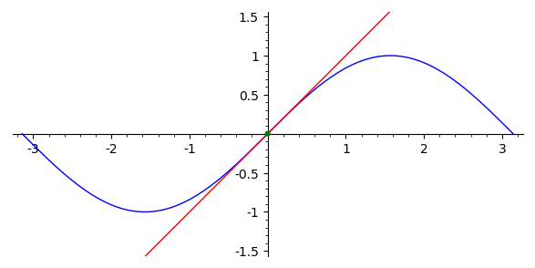

```python
grafico_f_tan(sin(x), 0, (-pi,pi), (-1.5, 1.5))
```

```python
y = var('y')
f = sin(x)
(y == diff(f, x)(x=0)*(x-0)+f(x=0)).show()
```

$$\newcommand{\Bold}[1]{\mathbf{#1}}y = x$$

## Exercício 8.

## Determine a equação da reta tangente ao gráfico de $f(x)=\cos(x)$ no ponto de abscissa $0$.

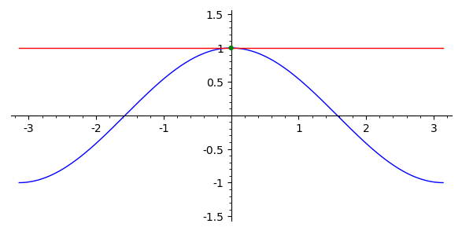

```python
grafico_f_tan(cos(x), 0, (-pi,pi), (-1.5, 1.5))
```

```python
y = var('y')
f = cos(x)
(y == diff(f, x)(x=0)*(x-0)+f(x=0)).show()
```

$$\newcommand{\Bold}[1]{\mathbf{#1}}y = 1$$